# Session 4: Homework 2

MFA Stream B - Group35

2020-10-04

# 1 Climate change and temperature anomalies

Loading the file:

```r
weather <-
  read_csv("https://data.giss.nasa.gov/gistemp/tabledata_v3/NH.Ts+dSST.csv",
           skip = 1,
           na = "***")
```

Selecting the year and the twelve month variables from the `weather` dataset, and converting the dataframe from wide to ‘long’ format.

```r
glimpse(weather)
```

```
## Rows: 140
## Columns: 19
## $ Year  <dbl> 1880, 1881, 1882, 1883, 1884, 1885, 1886, 1887, 1888, 1889, 1...
## $ Jan   <dbl> -0.54, -0.19, 0.22, -0.59, -0.23, -1.00, -0.68, -1.07, -0.53,...
## $ Feb   <dbl> -0.38, -0.25, 0.22, -0.67, -0.11, -0.37, -0.68, -0.58, -0.59,...
## $ Mar   <dbl> -0.26, 0.02, 0.00, -0.16, -0.65, -0.21, -0.57, -0.36, -0.58, ...
## $ Apr   <dbl> -0.37, -0.02, -0.36, -0.27, -0.62, -0.53, -0.34, -0.42, -0.24...
## $ May   <dbl> -0.11, -0.06, -0.32, -0.32, -0.42, -0.55, -0.34, -0.27, -0.16...
## $ Jun   <dbl> -0.22, -0.36, -0.38, -0.26, -0.52, -0.47, -0.43, -0.20, -0.04...
## $ Jul   <dbl> -0.23, -0.06, -0.37, -0.09, -0.48, -0.39, -0.20, -0.23, 0.04,...
## $ Aug   <dbl> -0.24, -0.03, -0.14, -0.26, -0.50, -0.44, -0.47, -0.52, -0.19...
## $ Sep   <dbl> -0.26, -0.23, -0.17, -0.33, -0.45, -0.32, -0.34, -0.17, -0.12...
## $ Oct   <dbl> -0.32, -0.40, -0.53, -0.21, -0.41, -0.30, -0.31, -0.40, 0.04,...
## $ Nov   <dbl> -0.37, -0.42, -0.32, -0.40, -0.48, -0.28, -0.45, -0.19, -0.03...
## $ Dec   <dbl> -0.48, -0.28, -0.42, -0.25, -0.40, 0.00, -0.17, -0.43, -0.26,...
## $ `J-D` <dbl> -0.32, -0.19, -0.21, -0.32, -0.44, -0.40, -0.42, -0.40, -0.22...
## $ `D-N` <dbl> NA, -0.21, -0.20, -0.33, -0.43, -0.44, -0.40, -0.38, -0.24, -...
## $ DJF   <dbl> NA, -0.31, 0.06, -0.56, -0.20, -0.59, -0.45, -0.61, -0.52, -0...
## $ MAM   <dbl> -0.24, -0.02, -0.22, -0.25, -0.56, -0.43, -0.42, -0.35, -0.33...
## $ JJA   <dbl> -0.23, -0.15, -0.30, -0.20, -0.50, -0.44, -0.37, -0.32, -0.06...
## $ SON   <dbl> -0.32, -0.35, -0.34, -0.32, -0.44, -0.30, -0.37, -0.25, -0.04...
```

```r
tidyweather <- weather %>% select(c(1:13)) %>%
  pivot_longer(cols = 2:13, names_to = "month", values_to = "delta")

glimpse(tidyweather)
```

```
## Rows: 1,680
## Columns: 3
## $ Year  <dbl> 1880, 1880, 1880, 1880, 1880, 1880, 1880, 1880, 1880, 1880, 1...
## $ month <chr> "Jan", "Feb", "Mar", "Apr", "May", "Jun", "Jul", "Aug", "Sep"...
## $ delta <dbl> -0.54, -0.38, -0.26, -0.37, -0.11, -0.22, -0.23, -0.24, -0.26...
```

## 1.1 Plotting Information

Plotting the data using a time-series scatter plot, and adding a trendline.

```r
tidyweather <- tidyweather %>%
  mutate(date = ymd(paste(as.character(Year), month, "1")),
         month = month(date, label=TRUE),
         year = year(date))

glimpse(tidyweather)
```

```
## Rows: 1,680
## Columns: 5
## $ Year  <dbl> 1880, 1880, 1880, 1880, 1880, 1880, 1880, 1880, 1880, 1880, 1...
## $ month <ord> Jan, Feb, Mar, Apr, May, Jun, Jul, Aug, Sep, Oct, Nov, Dec, J...
## $ delta <dbl> -0.54, -0.38, -0.26, -0.37, -0.11, -0.22, -0.23, -0.24, -0.26...
## $ date  <date> 1880-01-01, 1880-02-01, 1880-03-01, 1880-04-01, 1880-05-01, ...
## $ year  <dbl> 1880, 1880, 1880, 1880, 1880, 1880, 1880, 1880, 1880, 1880, 1...
```

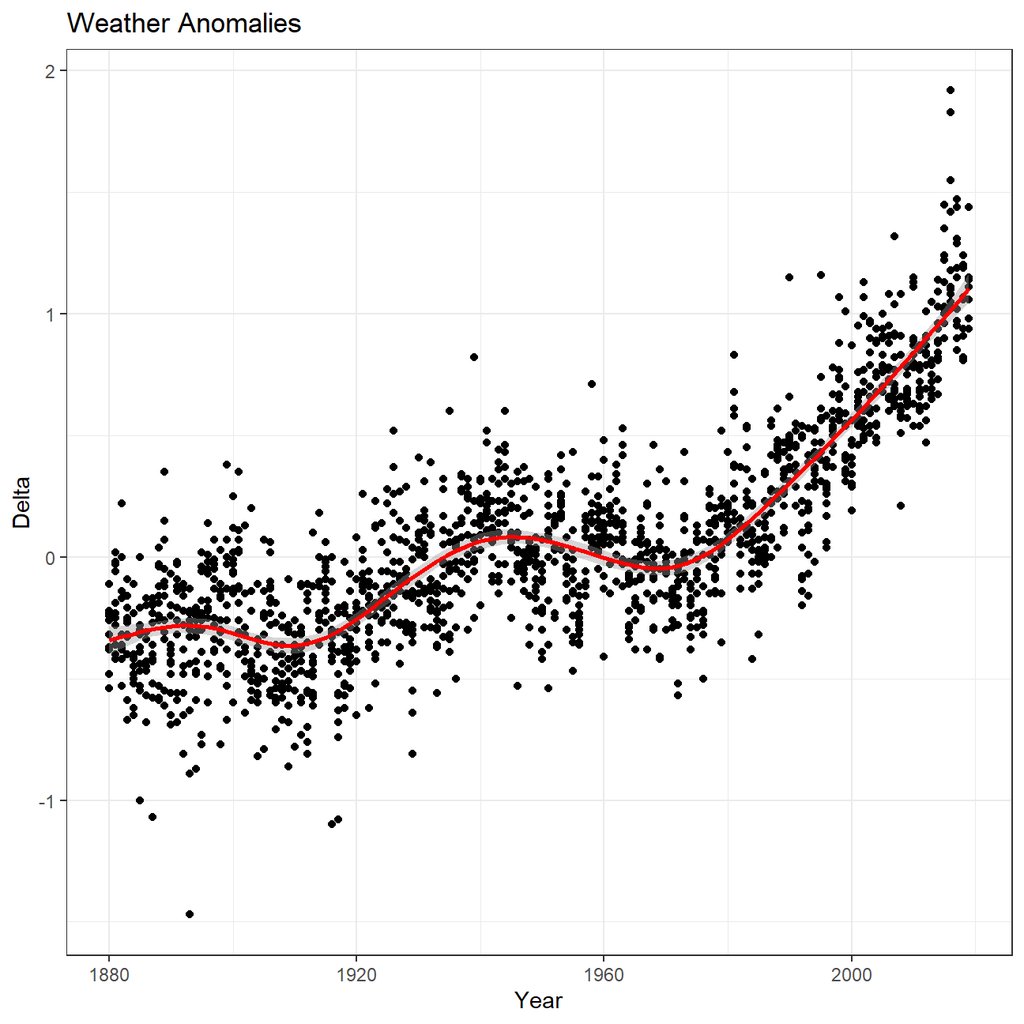

```r
ggplot(tidyweather, aes(x=year, y = delta))+
  geom_point()+
  geom_smooth(color="red") +
  theme_bw() +
  labs (
    title = "Weather Anomalies",
    y = "Delta",
    x = "Year"
  )
```

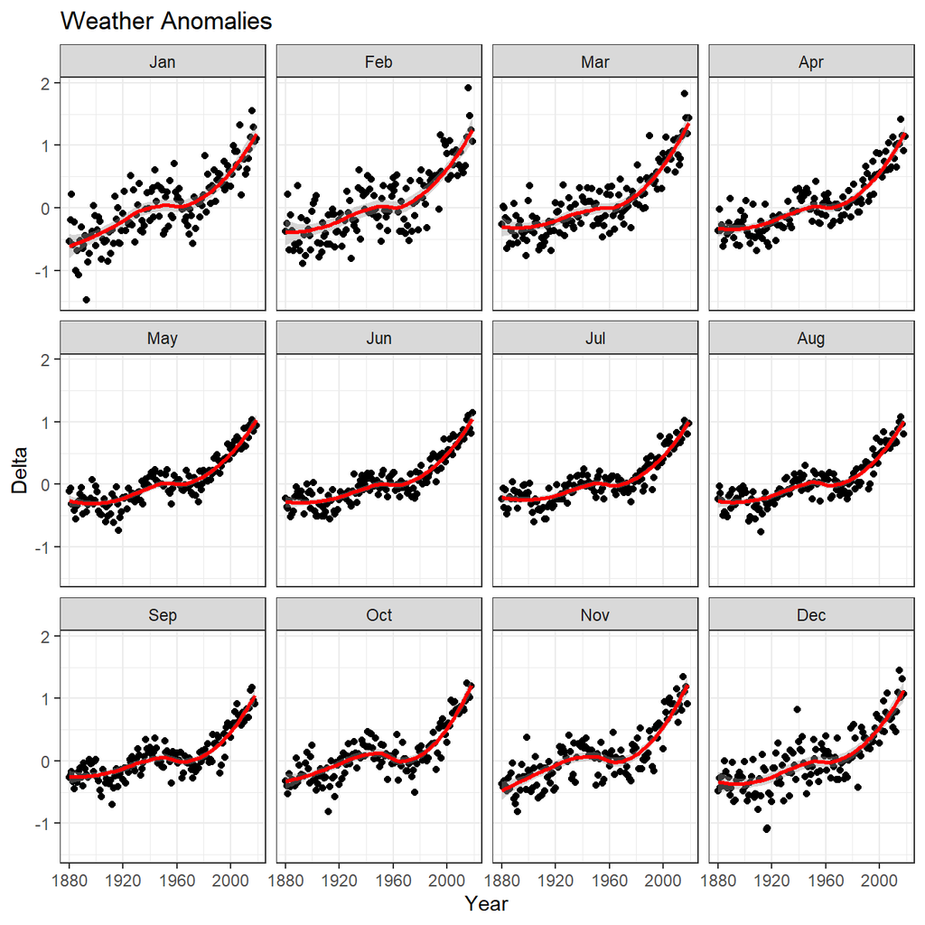

```r
ggplot(tidyweather, aes(x=year, y = delta))+
  geom_point()+
  geom_smooth(color="red") +
  facet_wrap(~month) +
  theme_bw() +
  labs (
    title = "Weather Anomalies",
    x = "Year",
    y = "Delta"
  )
```

We can see that the effect of increasing temperature is more pronounced in months Jan-April, where the delta is varying a lot and by greater extent.

```r
comparison <- tidyweather %>%
  filter(Year>= 1881) %>%     #remove years prior to 1881
  #create new variable 'interval', and assign values based on criteria below:
  mutate(interval = case_when(
    Year %in% c(1881:1920) ~ "1881-1920",
    Year %in% c(1921:1950) ~ "1921-1950",
    Year %in% c(1951:1980) ~ "1951-1980",
    Year %in% c(1981:2010) ~ "1981-2010",
    TRUE ~ "2011-present"
  ))

glimpse(comparison)
```

```
## Rows: 1,668
## Columns: 6
## $ Year     <dbl> 1881, 1881, 1881, 1881, 1881, 1881, 1881, 1881, 1881, 1881...
## $ month    <ord> Jan, Feb, Mar, Apr, May, Jun, Jul, Aug, Sep, Oct, Nov, Dec...
## $ delta    <dbl> -0.19, -0.25, 0.02, -0.02, -0.06, -0.36, -0.06, -0.03, -0....
## $ date     <date> 1881-01-01, 1881-02-01, 1881-03-01, 1881-04-01, 1881-05-0...
## $ year     <dbl> 1881, 1881, 1881, 1881, 1881, 1881, 1881, 1881, 1881, 1881...
## $ interval <chr> "1881-1920", "1881-1920", "1881-1920", "1881-1920", "1881-...
```

Creating a density plot to study the distribution of monthly deviations (`delta`), grouped by the different time periods.

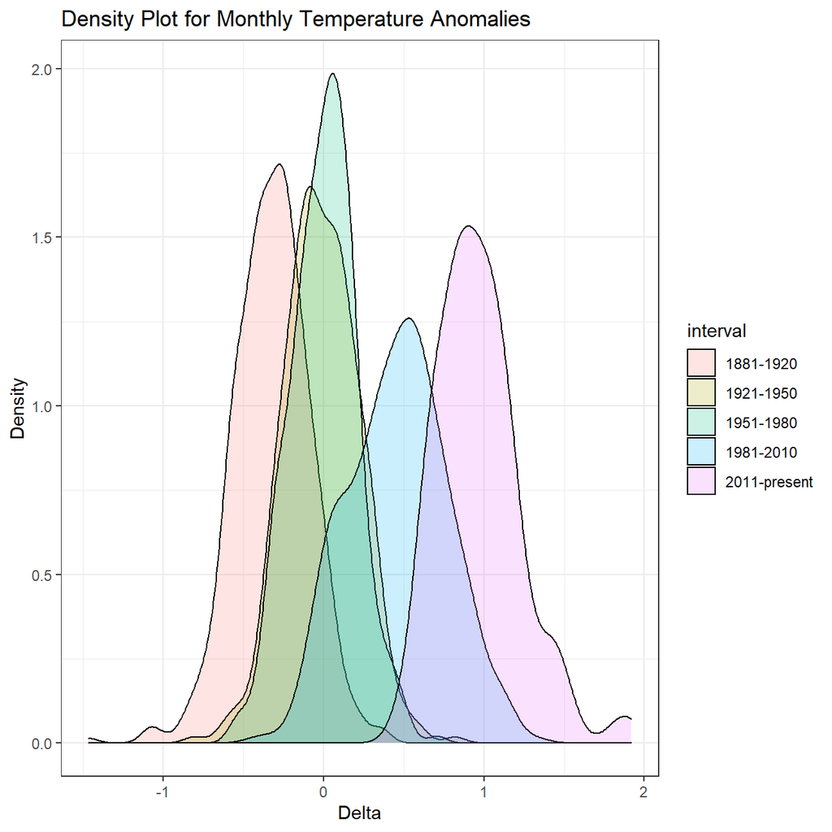

```r
ggplot(comparison, aes(x=delta, fill=interval))+
  geom_density(alpha=0.2) +   #density plot with tranparency set to 20%
  theme_bw() +                #theme
  labs (
    title = "Density Plot for Monthly Temperature Anomalies",
    y     = "Density",         #changing y-axis label to sentence case,
    x = "Delta"
  )
```

Average annual anomalies.

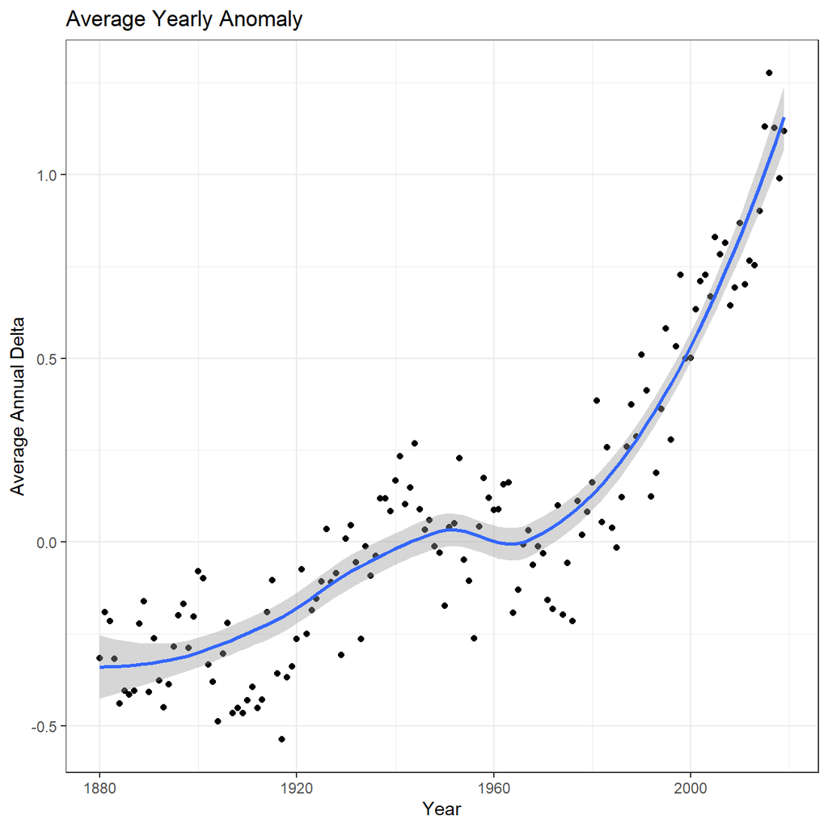

```r
#creating yearly averages
average_annual_anomaly <- tidyweather %>%
  group_by(year) %>%   #grouping data by Year

  # creating summaries for mean delta
  # use `na.rm=TRUE` to eliminate NA (not available) values
  summarise(annual_average_delta = mean(delta, na.rm=TRUE))

#plotting the data:
ggplot(average_annual_anomaly, aes(x=year, y= annual_average_delta))+
  geom_point()+

  #Fit the best fit line, using LOESS method
  geom_smooth() +

  #change to theme_bw() to have white background + black frame around plot
  theme_bw() +
  labs (
    title = "Average Yearly Anomaly",
    y     = "Average Annual Delta",
    x = "Year"
  )
```

## 1.2 Confidence Interval for `delta`

constructing a confidence interval for the average annual delta since 2011, using a formula.

```r
formula_ci <- comparison %>% filter(interval == "2011-present") %>%
  summarise(mean_delta = mean(delta, na.rm = TRUE),
            sd_delta = sd(delta, na.rm = TRUE),
            count_delta = n()) %>%
  mutate(se_delta = sd_delta / sqrt(count_delta),
         lower_ci = mean_delta - qt(1 - (0.05 / 2), count_delta - 1) * se_delta,
         upper_ci = mean_delta + qt(1 - (0.05 / 2), count_delta - 1) * se_delta)


#print out formula_CI
formula_ci
```

```
## # A tibble: 1 x 6
##   mean_delta sd_delta count_delta se_delta lower_ci upper_ci
##        <dbl>    <dbl>       <int>    <dbl>    <dbl>    <dbl>
## 1      0.966    0.262         108   0.0252    0.916     1.02
```

```r
# use the infer package to construct a 95% CI for delta
set.seed(1234)

bootstrap_data <- comparison %>% filter(interval == "2011-present") %>%
  specify(response = delta) %>%
  generate(reps=1000, type="bootstrap") %>%
  calculate(stat="mean")

ci_bootstrap <- bootstrap_data %>%
  get_confidence_interval(level = 0.95, type = "percentile")

ci_bootstrap
```

```
## # A tibble: 1 x 2
##   lower_ci upper_ci
##      <dbl>    <dbl>
## 1    0.917     1.02
```

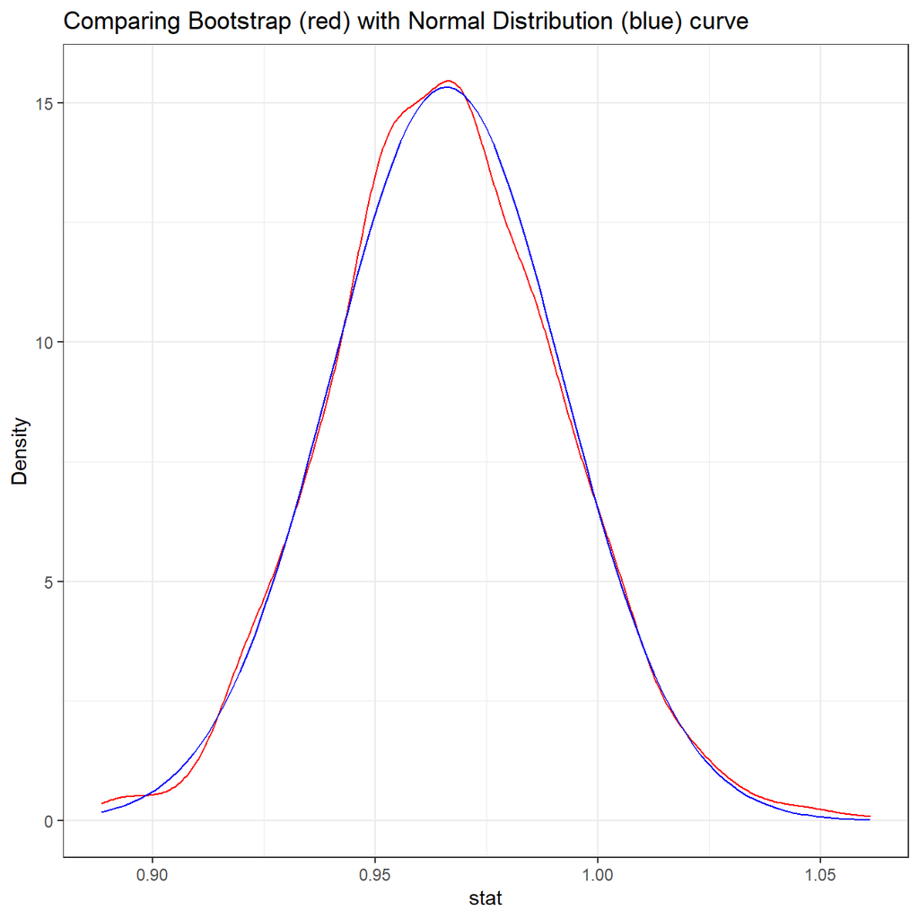

```r
ggplot(bootstrap_data, aes(x=stat)) +
  geom_density(color="red") +
  stat_function(fun = dnorm, color="blue", args = list(mean = mean(bootstrap_data$stat), sd = sd(bootstrap_data$stat))) +
  theme_bw() +
  labs(title = "Comparing Bootstrap (red) with Normal Distribution (blue) curve",
       y = "Density")
```

Data shows us that with 95% confidence we can say that average annual delta since 2011 lies between 0.92 and 1.02, which is a significant number. If this trend continues, it’d be too late reverse the impact and save our planet.

# 2 General Social Survey (GSS)

```r
gss <- read_csv(here::here("data", "smallgss2016.csv"),
                na = c("", "Don't know",
                       "No answer", "Not applicable"))

glimpse(gss)
```

```
## Rows: 2,867
## Columns: 7
## $ emailmin <chr> "0", "30", "NA", "10", "NA", "0", "0", "NA", "0", "NA", "0...
## $ emailhr  <chr> "12", "0", "NA", "0", "NA", "2", "40", "NA", "0", "NA", "2...
## $ snapchat <chr> "NA", "No", "No", "NA", "Yes", "No", "NA", "Yes", "NA", "N...
## $ instagrm <chr> "NA", "No", "No", "NA", "Yes", "Yes", "NA", "Yes", "NA", "...
## $ twitter  <chr> "NA", "No", "No", "NA", "No", "No", "NA", "No", "NA", "No"...
## $ sex      <chr> "Male", "Male", "Male", "Female", "Female", "Female", "Mal...
## $ degree   <chr> "Bachelor", "High school", "Bachelor", "High school", "Gra...
```

## 2.1 Instagram and Snapchat, by sex

Estimating the *population* proportion of Snapchat or Instagram users in 2016:

1. Creating a new variable, `snap_insta` that is *Yes* if the respondent reported using any of Snapchat (`snapchat`) or Instagram (`instagrm`), and *No* if not. If the recorded value was NA for both of these questions, the value in this new variable is also NA.

```r
gss <- gss %>% mutate(snap_insta = case_when(
  snapchat=="Yes"|instagrm=="Yes"~"Yes",
  snapchat=="No"|instagrm=="No"~"No",
  TRUE~"NA"))
```

2. Calculating the proportion of Yes’s for `snap_insta` among those who answered the question, i.e. excluding NAs.

```r
gss_snap_insta_cleaned <- gss %>%
  filter(snap_insta %in% c("Yes", "No")) %>%
  mutate(snap_insta_val = ifelse(snap_insta == "Yes", 1, 0))

snap_insta_prop <-  gss_snap_insta_cleaned %>%
  summarise(proportion=prop(snap_insta_val, success = 1))

snap_insta_prop
```

```
## # A tibble: 1 x 1
##   proportion
##        <dbl>
## 1      0.375
```

3. Constructing 95% CIs for men and women who used either Snapchat or Instagram

```r
formula_ci <- gss_snap_insta_cleaned %>% group_by(sex) %>%
  summarise(mean_sip= mean(snap_insta_val, na.rm = TRUE),
            sd_sip = sd(snap_insta_val, na.rm = TRUE),
            count_sip = n()) %>%
  mutate(se_sip = sd_sip / sqrt(count_sip),
         lower_ci = mean_sip - qt(1 - (0.05 / 2), count_sip - 1) * se_sip,
         upper_ci = mean_sip + qt(1 - (0.05 / 2), count_sip - 1) * se_sip)

formula_ci
```

```
## # A tibble: 2 x 7
##   sex    mean_sip sd_sip count_sip se_sip lower_ci upper_ci
##   <chr>     <dbl>  <dbl>     <int>  <dbl>    <dbl>    <dbl>
## 1 Female    0.419  0.494       769 0.0178    0.384    0.454
## 2 Male      0.318  0.466       603 0.0190    0.281    0.356
```

## 2.2 Twitter, by education level

Estimate the *population* proportion of Twitter users by education level in 2016.

There are 5 education levels in variable `degree` which, in ascneding order of years of education, are Lt high school, High School, Junior college, Bachelor, Graduate.

1. Turn `degree` from a character variable into a factor variable. Make sure the order is the correct one and that levels are not sorted alphabetically which is what R by default does.

```r
gss_degree_cleaned <- gss %>% filter(!degree %in% c("NA"))
gss_degree_cleaned$degree <- factor(gss_degree_cleaned$degree, ordered=TRUE, levels = c("Lt high school","High school", "Junior college", "Bachelor", "Graduate"))

unique(gss_degree_cleaned$degree)
```

```
## [1] Bachelor       High school    Graduate       Junior college Lt high school
## 5 Levels: Lt high school < High school < Junior college < ... < Graduate
```

2. Create a new variable, `bachelor_graduate` that is *Yes* if the respondent has either a `Bachelor` or `Graduate` degree. As before, if the recorded value for either was NA, the value in your new variable should also be NA.

```r
gss <- gss %>% mutate(bachelor_graduate = case_when(degree=="Bachelor"|degree=="Graduate"~"Yes", degree=="NA"~"NA",
                                                    TRUE~"No"))

gss
```

```
## # A tibble: 2,867 x 9
##    emailmin emailhr snapchat instagrm twitter sex   degree snap_insta
##    <chr>    <chr>   <chr>    <chr>    <chr>   <chr> <chr>  <chr>
##  1 0        12      NA       NA       NA      Male  Bache~ NA
##  2 30       0       No       No       No      Male  High ~ No
##  3 NA       NA      No       No       No      Male  Bache~ No
##  4 10       0       NA       NA       NA      Fema~ High ~ NA
##  5 NA       NA      Yes      Yes      No      Fema~ Gradu~ Yes
##  6 0        2       No       Yes      No      Fema~ Junio~ Yes
##  7 0        40      NA       NA       NA      Male  High ~ NA
##  8 NA       NA      Yes      Yes      No      Fema~ High ~ Yes
##  9 0        0       NA       NA       NA      Male  High ~ NA
## 10 NA       NA      No       No       No      Male  Junio~ No
## # ... with 2,857 more rows, and 1 more variable: bachelor_graduate <chr>
```

3. Calculate the proportion of `bachelor_graduate` who do (Yes) and who don’t (No) use twitter.

```r
twitter_prop_yes <- gss %>%
  filter(bachelor_graduate == "Yes" & !twitter %in% "NA") %>%
  summarise(proportion=count(twitter=="Yes")/n())

twitter_prop_yes
```

```
## # A tibble: 1 x 1
##   proportion
##        <dbl>
## 1      0.233
```

```r
twitter_prop_no <- gss %>%
  filter(bachelor_graduate == "Yes" & !twitter %in% "NA") %>%
  summarise(proportion=count(twitter=="No")/n())

twitter_prop_no
```

```
## # A tibble: 1 x 1
##   proportion
##        <dbl>
## 1      0.767
```

4. Using the CI formula for proportions, please construct two 95% CIs for `bachelor_graduate` vs whether they use (Yes) and don’t (No) use twitter.

```r
twitter_yes <- gss %>%
  filter(bachelor_graduate=="Yes" & !twitter %in% "NA") %>%
  mutate(twitter_val = ifelse(twitter == "Yes", 1, 0)) %>%
  summarise(mean_val= mean(twitter_val, na.rm=TRUE),
            sd_val = sd(twitter_val, na.rm=TRUE),
            count = n()) %>%
  mutate(se = sd_val / sqrt(count),
         lower_ci = mean_val - qt(1 - (0.05 / 2), count - 1) * se,
         upper_ci = mean_val + qt(1 - (0.05 / 2), count - 1) * se)

twitter_yes
```

```
## # A tibble: 1 x 6
##   mean_val sd_val count     se lower_ci upper_ci
##      <dbl>  <dbl> <int>  <dbl>    <dbl>    <dbl>
## 1    0.233  0.423   489 0.0191    0.196    0.271
```

```r
twitter_no <- gss %>%
  filter(bachelor_graduate=="Yes" & !twitter %in% "NA") %>%
  mutate(twitter_val = ifelse(twitter == "No", 1, 0)) %>%
  summarise(mean_val= mean(twitter_val, na.rm=TRUE),
            sd_val = sd(twitter_val, na.rm=TRUE),
            count = n()) %>%
  mutate(se = sd_val / sqrt(count),
         lower_ci = mean_val - qt(1 - (0.05 / 2), count - 1) * se,
         upper_ci = mean_val + qt(1 - (0.05 / 2), count - 1) * se)

twitter_no
```

```
## # A tibble: 1 x 6
##   mean_val sd_val count     se lower_ci upper_ci
##      <dbl>  <dbl> <int>  <dbl>    <dbl>    <dbl>
## 1    0.767  0.423   489 0.0191    0.729    0.804
```

5. Do these two Confidence Intervals overlap? No, these don’t overlap.

## 2.3 Email usage

Can we estimate the *population* parameter on time spent on email weekly?

1. Create a new variable called `email` that combines `emailhr` and `emailmin` to reports the number of minutes the respondents spend on email weekly.

```r
gss$emailhr <- as.numeric(gss$emailhr)
gss$emailmin <- as.numeric(gss$emailmin)

gss_email <- gss %>% filter(!is.na(emailhr) & !is.na(emailmin)) %>%
  mutate(email = emailhr*60+emailmin)

gss_email
```

```
## # A tibble: 1,649 x 10
##    emailmin emailhr snapchat instagrm twitter sex   degree snap_insta
##       <dbl>   <dbl> <chr>    <chr>    <chr>   <chr> <chr>  <chr>
##  1        0      12 NA       NA       NA      Male  Bache~ NA
##  2       30       0 No       No       No      Male  High ~ No
##  3       10       0 NA       NA       NA      Fema~ High ~ NA
##  4        0       2 No       Yes      No      Fema~ Junio~ Yes
##  5        0      40 NA       NA       NA      Male  High ~ NA
##  6        0       0 NA       NA       NA      Male  High ~ NA
##  7        0       2 No       No       No      Fema~ High ~ No
##  8        0      10 No       No       No      Male  High ~ No
##  9       30       0 No       No       No      Male  Lt hi~ No
## 10        0       1 NA       NA       NA      Fema~ Lt hi~ NA
## # ... with 1,639 more rows, and 2 more variables: bachelor_graduate <chr>,
## #   email <dbl>
```

2. Visualise the distribution of this new variable. Find the mean and the median number of minutes respondents spend on email weekly. Is the mean or the median a better measure of the typical amoung of time Americans spend on email weekly? Why?

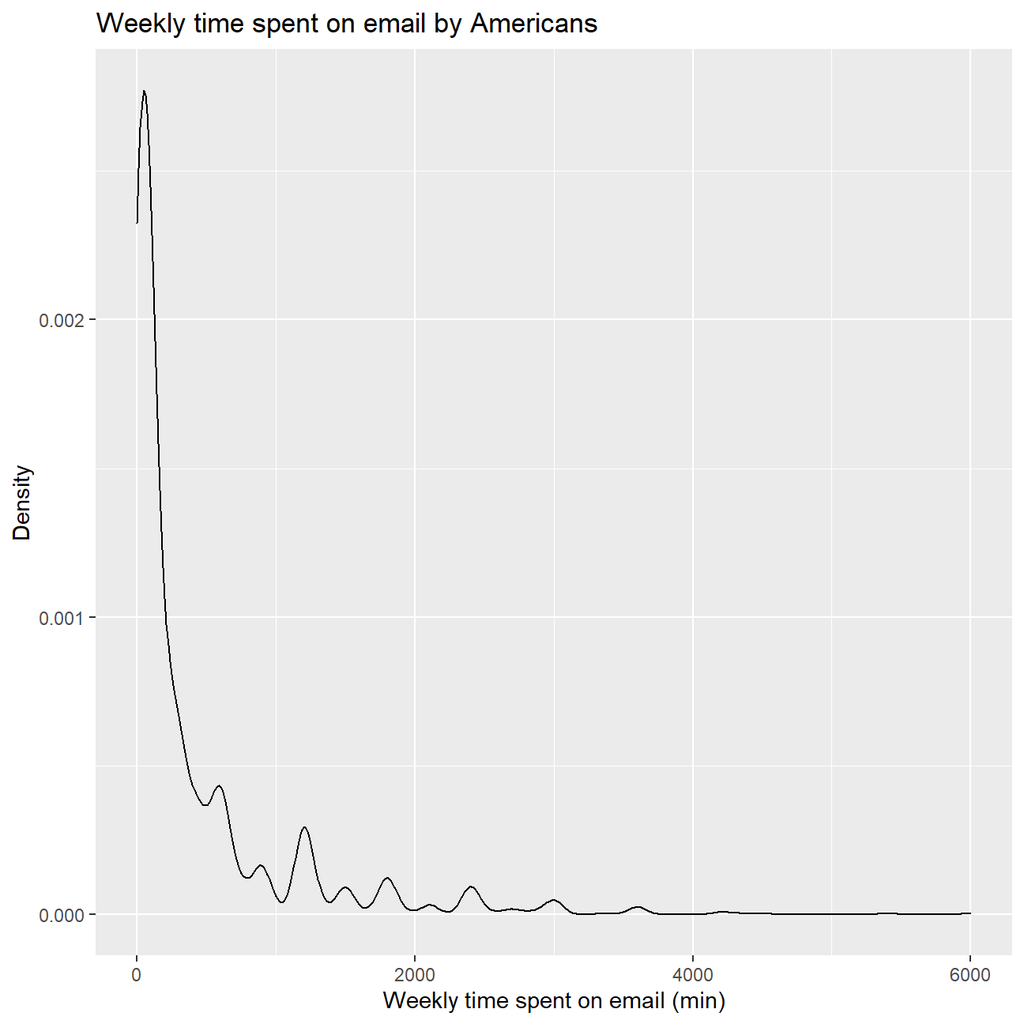

```r
ggplot(gss_email, aes(x=email)) + geom_density() +labs(title="Weekly time spent on email by Americans", x="Weekly time spent on email (min)", y="Density")
```

```r
mean_median <- gss_email %>% summarise(mean_email=mean(email, na.rm=TRUE), median_email=median(email, na.rm=TRUE))

mean_median
```

```
## # A tibble: 1 x 2
##   mean_email median_email
##        <dbl>        <dbl>
## 1       417.          120
```

3. Using the `infer` package, calculate a 95% bootstrap confidence interval for the mean amount of time Americans spend on email weekly. Interpret this interval in context of the data, reporting its endpoints in “humanized” units (e.g. instead of 108 minutes, report 1 hr and 8 minutes). If you get a result that seems a bit odd, discuss why you think this might be the case.

```r
set.seed(1234)

email_ci_bootstrap <- gss_email %>% filter(!is.na(email)) %>%
  specify(response = email) %>%
  generate(reps=1000, type="bootstrap") %>%
  calculate(stat="mean") %>%
  get_confidence_interval(level = 0.95, type = "percentile")

email_ci_bootstrap
```

```
## # A tibble: 1 x 2
##   lower_ci upper_ci
##      <dbl>    <dbl>
## 1     385.     453.
```

```r
pretty_ci <- email_ci_bootstrap %>%  mutate(lower_ci_hour=lower_ci%/%60, lower_ci_minute=round(lower_ci%%60,0),upper_ci_hour=upper_ci%/%60, upper_ci_minute=round(upper_ci%%60,0))

pretty_ci
```

```
## # A tibble: 1 x 6
##   lower_ci upper_ci lower_ci_hour lower_ci_minute upper_ci_hour upper_ci_minute
##      <dbl>    <dbl>         <dbl>           <dbl>         <dbl>           <dbl>
## 1     385.     453.             6              25             7              33
```

```r
paste("Lower ci: ", pretty_ci$lower_ci_hour,"hours and", pretty_ci$lower_ci_minute, "minutes")
```

```
## [1] "Lower ci:  6 hours and 25 minutes"
```

```r
paste("Upper ci:", pretty_ci$upper_ci_hour, "hours and", pretty_ci$upper_ci_minute, "minutes")
```

```
## [1] "Upper ci: 7 hours and 33 minutes"
```

4. Would you expect a 99% confidence interval to be wider or narrower than the interval you calculated above? Explain your reasoning. In theory, a 99% confidence interval would be expected to be wider. It should encompass more values than the 95% ci in order to be 99% sure that the time spent on email weekly would fall in the confidence interval.

# 3 Trump’s Approval Margins

```r
# Import approval polls data
approval_polllist <- read_csv(here::here('data', 'approval_polllist.csv'))

# or directly off fivethirtyeight website
# approval_polllist <- read_csv('https://projects.fivethirtyeight.com/trump-approval-data/approval_polllist.csv')

glimpse(approval_polllist)
```

```
## Rows: 15,619
## Columns: 22
## $ president           <chr> "Donald Trump", "Donald Trump", "Donald Trump",...
## $ subgroup            <chr> "All polls", "All polls", "All polls", "All pol...
## $ modeldate           <chr> "9/27/2020", "9/27/2020", "9/27/2020", "9/27/20...
## $ startdate           <chr> "1/20/2017", "1/20/2017", "1/20/2017", "1/21/20...
## $ enddate             <chr> "1/22/2017", "1/22/2017", "1/24/2017", "1/23/20...
## $ pollster            <chr> "Gallup", "Morning Consult", "Ipsos", "Gallup",...
## $ grade               <chr> "B", "B/C", "B-", "B", "B-", "C+", "B+", "B", "...
## $ samplesize          <dbl> 1500, 1992, 1632, 1500, 1651, 1500, 1190, 1500,...
## $ population          <chr> "a", "rv", "a", "a", "a", "lv", "rv", "a", "lv"...
## $ weight              <dbl> 0.262, 0.680, 0.153, 0.243, 0.142, 0.200, 1.514...
## $ influence           <dbl> 0, 0, 0, 0, 0, 0, 0, 0, 0, 0, 0, 0, 0, 0, 0, 0,...
## $ approve             <dbl> 45.0, 46.0, 42.1, 45.0, 42.3, 57.0, 36.0, 46.0,...
## $ disapprove          <dbl> 45.0, 37.0, 45.2, 46.0, 45.8, 43.0, 44.0, 45.0,...
## $ adjusted_approve    <dbl> 45.7, 45.3, 43.2, 45.7, 43.4, 51.5, 37.6, 46.7,...
## $ adjusted_disapprove <dbl> 43.6, 38.3, 43.9, 44.6, 44.5, 44.5, 42.8, 43.6,...
## $ multiversions       <chr> NA, NA, NA, NA, NA, NA, NA, NA, NA, NA, NA, NA,...
## $ tracking            <lgl> TRUE, NA, TRUE, TRUE, TRUE, TRUE, NA, TRUE, TRU...
## $ url                 <chr> "http://www.gallup.com/poll/201617/gallup-daily...
## $ poll_id             <dbl> 49253, 49249, 49426, 49262, 49425, 49266, 49260...
## $ question_id         <dbl> 77265, 77261, 77599, 77274, 77598, 77278, 77272...
## $ createddate         <chr> "1/23/2017", "1/23/2017", "3/1/2017", "1/24/201...
## $ timestamp           <chr> "00:45:20 27 Sep 2020", "00:45:20 27 Sep 2020",...
```

```r
# Use `lubridate` to fix dates, as they are given as characters.
```

```r
# Use `lubridate` to fix dates, as they are given as characters.

library(lubridate)
approval_polllist_converted <- approval_polllist %>%
  mutate(modeldate = mdy(modeldate),
         startdate = mdy(startdate),
         enddate = mdy(enddate))

approval_polllist_converted
```

```
## # A tibble: 15,619 x 22
##    president subgroup modeldate  startdate  enddate    pollster grade samplesize
##    <chr>     <chr>    <date>     <date>     <date>     <chr>    <chr>      <dbl>
##  1 Donald T~ All pol~ 2020-09-27 2017-01-20 2017-01-22 Gallup   B           1500
##  2 Donald T~ All pol~ 2020-09-27 2017-01-20 2017-01-22 Morning~ B/C         1992
##  3 Donald T~ All pol~ 2020-09-27 2017-01-20 2017-01-24 Ipsos    B-          1632
##  4 Donald T~ All pol~ 2020-09-27 2017-01-21 2017-01-23 Gallup   B           1500
##  5 Donald T~ All pol~ 2020-09-27 2017-01-21 2017-01-25 Ipsos    B-          1651
##  6 Donald T~ All pol~ 2020-09-27 2017-01-22 2017-01-24 Rasmuss~ C+          1500
##  7 Donald T~ All pol~ 2020-09-27 2017-01-20 2017-01-25 Quinnip~ B+          1190
##  8 Donald T~ All pol~ 2020-09-27 2017-01-22 2017-01-24 Gallup   B           1500
##  9 Donald T~ All pol~ 2020-09-27 2017-01-23 2017-01-25 Rasmuss~ C+          1500
## 10 Donald T~ All pol~ 2020-09-27 2017-01-23 2017-01-25 Gallup   B           1500
## # ... with 15,609 more rows, and 14 more variables: population <chr>,
## #   weight <dbl>, influence <dbl>, approve <dbl>, disapprove <dbl>,
## #   adjusted_approve <dbl>, adjusted_disapprove <dbl>, multiversions <chr>,
## #   tracking <lgl>, url <chr>, poll_id <dbl>, question_id <dbl>,
## #   createddate <chr>, timestamp <chr>
```

## 3.1 Create a plot

Calculating the average net approval rate (approve- disapprove) for each week since President Trump got into office.

Image to plot:

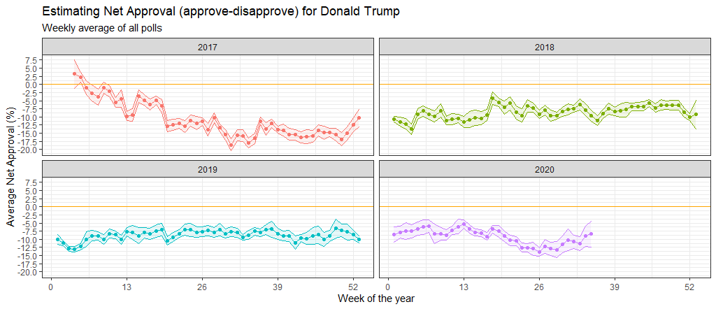

```r
weekly_net_approval <- approval_polllist_converted %>% filter(subgroup == "Voters") %>%
  mutate(net_approval = approve - disapprove,
         week = isoweek(enddate),
         year = year(enddate)) %>%
  group_by(year, week) %>%
  summarise(mean_weekly_nar = mean(net_approval),
            sd_weekly_nar = sd(net_approval),
            count_weekly_nar = n(),
            t_distribution=qt(0.975, count_weekly_nar-1),
            se_weekly_nar = sd_weekly_nar/sqrt(count_weekly_nar),
            interval_value=t_distribution*se_weekly_nar,
            low_ci=mean_weekly_nar-interval_value,
            high_ci=mean_weekly_nar+interval_value) %>%
  na.omit()

weekly_net_approval
```

```
## # A tibble: 192 x 10
## # Groups:   year [4]
##     year  week mean_weekly_nar sd_weekly_nar count_weekly_nar t_distribution
##    <dbl> <dbl>           <dbl>         <dbl>            <int>          <dbl>
##  1  2017     4           2.96           7.67               14           2.16
##  2  2017     5           1.85           3.67               20           2.09
##  3  2017     6          -2.06           5.82               25           2.06
##  4  2017     7          -2.46           6.35               25           2.06
##  5  2017     8          -3.32           5.96               23           2.07
##  6  2017     9          -0.704          3.81               23           2.07
##  7  2017    10          -3.13           4.49               25           2.06
##  8  2017    11          -4.67           4.43               25           2.06
##  9  2017    12          -5.6            6.71               24           2.07
## 10  2017    13          -9.89           3.94               25           2.06
## # ... with 182 more rows, and 4 more variables: se_weekly_nar <dbl>,
## #   interval_value <dbl>, low_ci <dbl>, high_ci <dbl>
```

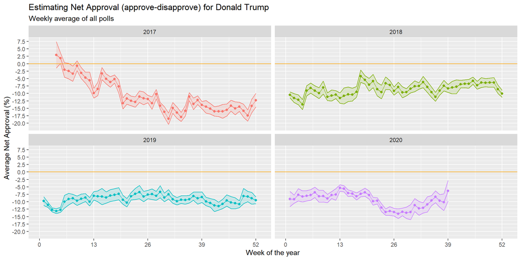

```r
ggplot(weekly_net_approval, aes(x = week, y = mean_weekly_nar, colour=factor(year))) +
  facet_wrap(~year) +
  geom_ribbon(aes(ymin = low_ci, ymax = high_ci, colour=factor(year), fill=factor(year)), alpha=0.15) +
  scale_x_continuous(breaks = seq(0,53, by = 13), limits = c(0,53)) +
  scale_y_continuous(breaks = seq(-20,7.5, by = 2.5), limits = c(-21,7.5)) +
  geom_hline(yintercept=0, color='orange') +
  geom_point() +
  geom_line() +
  theme(legend.position = "none") +
  ggtitle("Estimating Net Approval (approve-disapprove) for Donald Trump", subtitle = "Weekly average of all polls") +
  labs(y="Average Net Approval (%)", x="Week of the year")
```

## 3.2 Compare Confidence Intervals

Comparing the confidence intervals for `week 15` (6-12 April 2020) and `week 34` (17-23 August 2020).

```r
ci_wna <- weekly_net_approval %>%
  mutate(ci = interval_value * 2)

ci_wna
```

```
## # A tibble: 192 x 11
## # Groups:   year [4]
##     year  week mean_weekly_nar sd_weekly_nar count_weekly_nar t_distribution
##    <dbl> <dbl>           <dbl>         <dbl>            <int>          <dbl>
##  1  2017     4           2.96           7.67               14           2.16
##  2  2017     5           1.85           3.67               20           2.09
##  3  2017     6          -2.06           5.82               25           2.06
##  4  2017     7          -2.46           6.35               25           2.06
##  5  2017     8          -3.32           5.96               23           2.07
##  6  2017     9          -0.704          3.81               23           2.07
##  7  2017    10          -3.13           4.49               25           2.06
##  8  2017    11          -4.67           4.43               25           2.06
##  9  2017    12          -5.6            6.71               24           2.07
## 10  2017    13          -9.89           3.94               25           2.06
## # ... with 182 more rows, and 5 more variables: se_weekly_nar <dbl>,
## #   interval_value <dbl>, low_ci <dbl>, high_ci <dbl>, ci <dbl>
```

```r
subset(ci_wna, year==2020 & week==15)$ci
```

```
## [1] 2.22
```

```r
subset(ci_wna, year==2020 & week==34)$ci
```

```
## [1] 5.15
```

Apart from the very beginning of 2017, the Trump Approval Rate (TAR) has been consistently negative, characterized by a sensible amount of variability throughout time. The graphs shows that there have been periods in which the estimate of the Average TAR was fairly accurate, with a tight CI (as for the beginning of 2019 or April-May 2020). In other cases, like end of 2017-beginning of 2018, the true Average TAR has been much harder to infer from the data at our disposal.

It appears that, with the US presidential elections coming up in November 2020, it will be much harder to know the true Average TAR since the CI in the last 20 weeks has been consistently increasing, thus making the prediction of the TAR mean less certain.

# 4 Gapminder revisited

```r
# load gapminder HIV data
adults_with_hiv_percent_age_15_49 <- read_csv(here::here("data","adults_with_hiv_percent_age_15_49.csv"))
life_expectancy_years <- read_csv(here::here("data","life_expectancy_years.csv"))

# get World bank data using wbstats
indicators <- c("SP.DYN.TFRT.IN","SE.PRM.NENR", "SH.DYN.MORT", "NY.GDP.PCAP.KD")


library(wbstats)

worldbank_data <- wb_data(country="countries_only", #countries only- no aggregates like Latin America, Europe, etc.
                          indicator = indicators,
                          start_date = 1960,
                          end_date = 2016)

# get a dataframe of information regarding countries, indicators, sources, regions, indicator topics, lending types, income levels,  from the World Bank API
countries <-  wbstats::wb_cachelist$countries
```

1. Relationship between HIV prevalence and life expectancy.

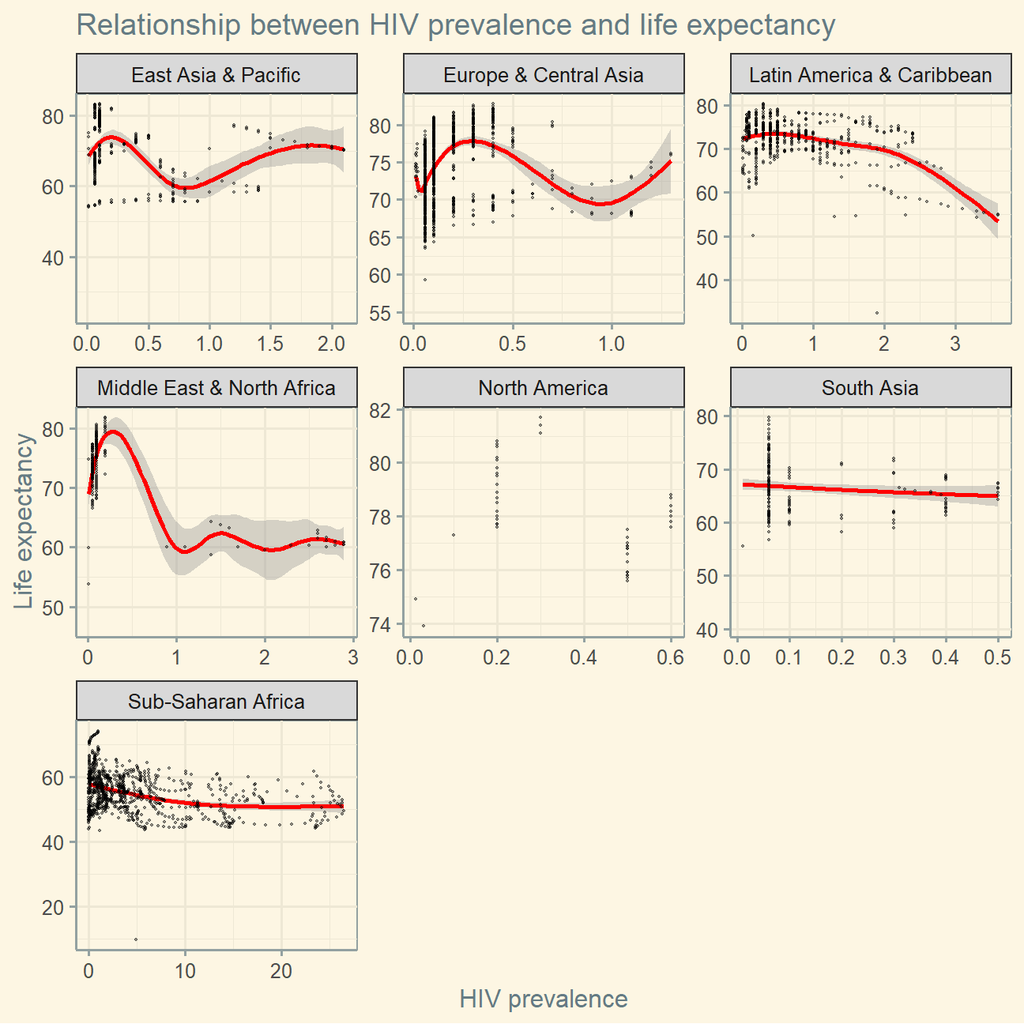

```r
Mutatation_life_expectancy <- life_expectancy_years%>%
  select(country,"1979":"2011")%>%
  pivot_longer(cols="1979":"2011",
               names_to="year",
               values_to="life_expectancy")

Mutation_HIV_prevalence <- adults_with_hiv_percent_age_15_49%>%
  select(country,"1979":"2011")%>%
  pivot_longer(cols="1979":"2011",
               names_to="year",
               values_to="HIV_prevalence")

Combined_data<-inner_join(Mutatation_life_expectancy,Mutation_HIV_prevalence,by=c("country","year"))
Combined_data<-inner_join(countries,Combined_data,by="country")

ggplot(Combined_data, aes(y=life_expectancy,x=HIV_prevalence))+
    geom_smooth(colour="red")+
           geom_point(alpha = 0.4, size=0.4)+
           facet_wrap(~region, scales="free")+
    labs(title="Relationship between HIV prevalence and life expectancy",y="Life expectancy",x="HIV prevalence") +
  theme_solarized()
```

Needed to have years as a column because earlier column headers were values not variable names.

2. Relationship between fertility rate and GDP per capita.

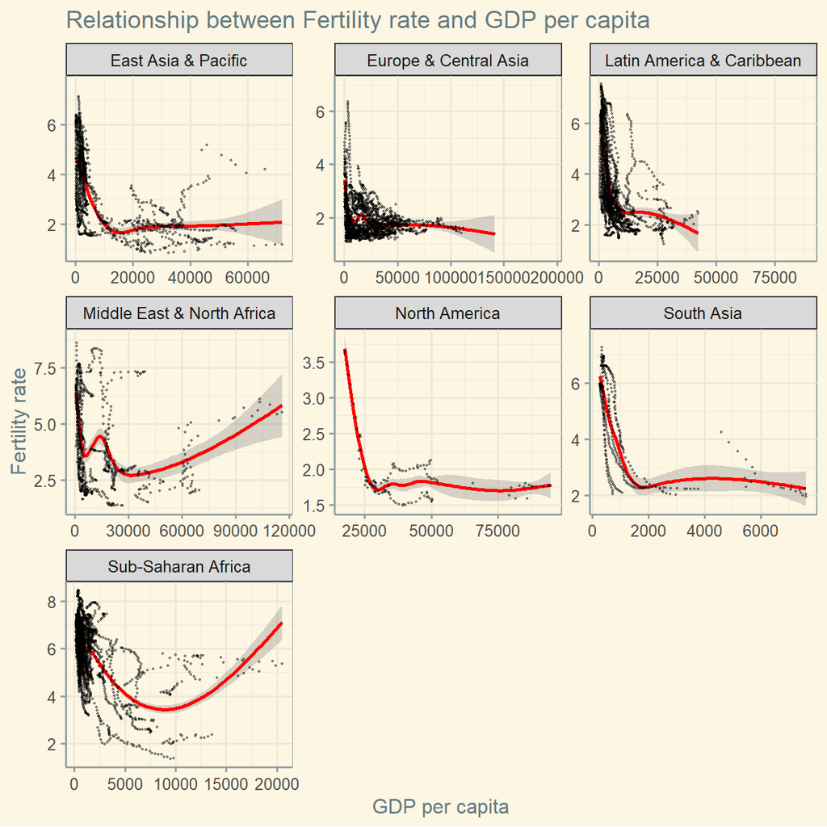

```r
Combined_data_2 <- inner_join(countries,worldbank_data,by="country")

ggplot(Combined_data_2, aes(x=NY.GDP.PCAP.KD,y=SP.DYN.TFRT.IN))+
    geom_smooth(colour="red")+
           geom_point(alpha=0.4, size=0.4)+
           facet_wrap(~region, scales = "free")+
    labs(title="Relationship between Fertility rate and GDP per capita",x="GDP per capita",y="Fertility rate") +
  theme_solarized()
```

3. Regions with most observations of missing HIV data.

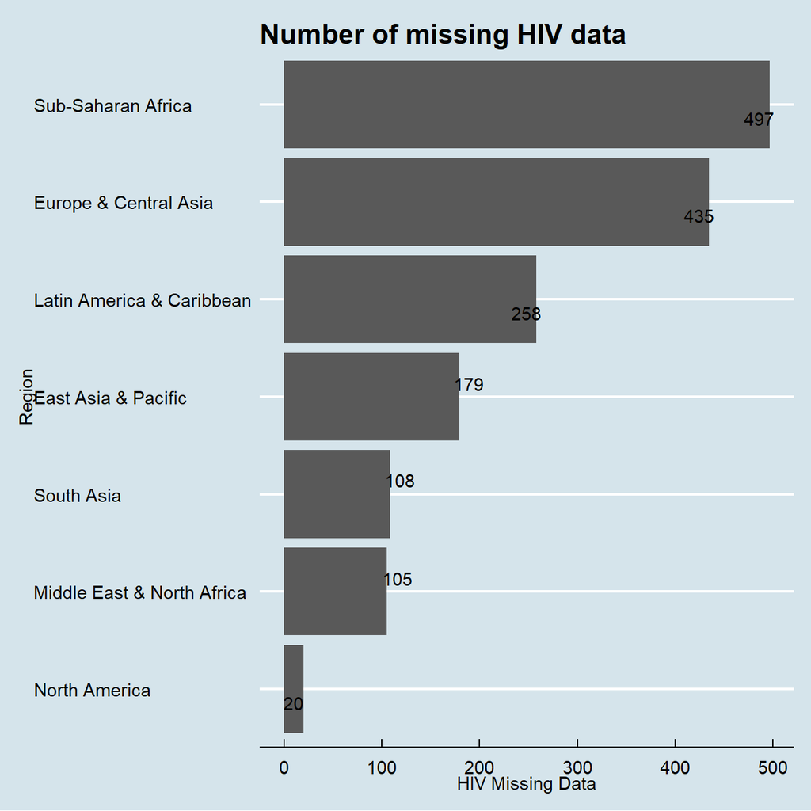

```r
Combined_data_3 <- Combined_data %>%
    filter(is.na(HIV_prevalence)) %>%
    group_by(region) %>%
    summarise(count=count(region))
    ggplot(Combined_data_3,aes(x=count,y=reorder(region,count)))+
    geom_col()+
    geom_text_repel(aes(label = count)) +
    theme_economist()+
    labs(title="Number of missing HIV data",x="HIV Missing Data",y="Region")
```

4. Top 5 countries that have seen the greatest improvement in mortality rates, as well as those 5 countries where mortality rates have had the least improvement or even deterioration.

```r
cleaned_data_latest <- Combined_data_2 %>% filter(!is.na(SH.DYN.MORT)) %>% group_by(region, country) %>%
  top_n(n=1, wt=date) %>% select(region, country, SH.DYN.MORT, date)

cleaned_data_oldest <- Combined_data_2 %>% filter(!is.na(SH.DYN.MORT)) %>% group_by(region, country) %>%
  top_n(n=1, wt=-date) %>% select(region, country, SH.DYN.MORT, date)

improvement_data <- cleaned_data_latest %>% inner_join(cleaned_data_oldest,
                                                       by=c("region", "country"),
                                                       suffix = c("_latest", "_oldest")) %>%
  mutate(improvement = -((SH.DYN.MORT_latest - SH.DYN.MORT_oldest)/SH.DYN.MORT_oldest)*100.0) #negative sign because reduction in mortality is actually improvement in mortality
improvement_data
```

```
## # A tibble: 193 x 7
## # Groups:   region, country [193]
##    region country SH.DYN.MORT_lat~ date_latest SH.DYN.MORT_old~ date_oldest
##    <chr>  <chr>              <dbl>       <dbl>            <dbl>       <dbl>
##  1 South~ Afghan~             67.6        2016            345.         1962
##  2 Sub-S~ Angola              84.2        2016            237.         1980
##  3 Europ~ Albania              9.4        2016             96.2        1978
##  4 Europ~ Andorra              3.4        2016             17.1        1985
##  5 Middl~ United~              7.8        2016            200.         1960
##  6 Latin~ Argent~             10.9        2016             72.5        1969
##  7 Europ~ Armenia             13.7        2016             86.2        1976
##  8 Latin~ Antigu~              7.4        2016             86.2        1960
##  9 East ~ Austra~              3.8        2016             24.8        1960
## 10 Europ~ Austria              3.6        2016             42.8        1960
## # ... with 183 more rows, and 1 more variable: improvement <dbl>
```

```r
top_5_improvements_by_region <- improvement_data %>% group_by(region) %>% top_n(n=5, wt=improvement) %>% arrange(region, -improvement)
top_5_improvements_by_region
```

```
## # A tibble: 32 x 7
## # Groups:   region [7]
##    region country SH.DYN.MORT_lat~ date_latest SH.DYN.MORT_old~ date_oldest
##    <chr>  <chr>              <dbl>       <dbl>            <dbl>       <dbl>
##  1 East ~ Korea,~              3.4        2016            112.         1960
##  2 East ~ Singap~              2.7        2016             47.7        1960
##  3 East ~ Japan                2.7        2016             39.7        1960
##  4 East ~ Thaila~             10.3        2016            146.         1960
##  5 East ~ China                9.9        2016            118.         1969
##  6 Europ~ Portug~              3.6        2016            114.         1960
##  7 Europ~ Turkey              12.1        2016            257.         1960
##  8 Europ~ Italy                3.4        2016             51.9        1960
##  9 Europ~ Cyprus               2.6        2016             38.2        1971
## 10 Europ~ Poland               4.7        2016             65.1        1960
## # ... with 22 more rows, and 1 more variable: improvement <dbl>
```

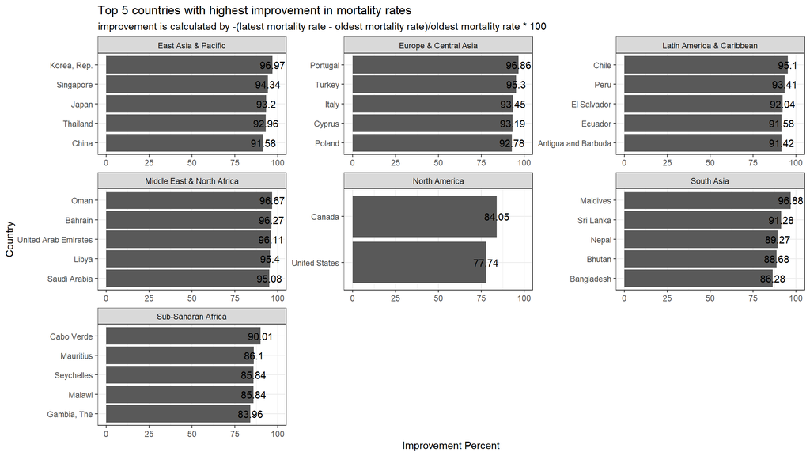

```r
ggplot(top_5_improvements_by_region, aes(x=improvement, y=reorder(country, improvement))) +
  geom_col() +
  xlim(0, 100) +
  facet_wrap(~region, scales = "free") +
  labs(title="Top 5 countries with highest improvement in mortality rates",
       subtitle="improvement is calculated by -(latest mortality rate - oldest mortality rate)/oldest mortality rate * 100",
       x = "Improvement Percent",
       y = "Country") +
  geom_text(aes(label = improvement %>% round(2))) +
  theme_bw()
```

```r
bottom_5_improvements_by_region <- improvement_data %>% group_by(region) %>% top_n(n=5, wt=-improvement) %>% arrange(region, improvement)
bottom_5_improvements_by_region
```

```
## # A tibble: 32 x 7
## # Groups:   region [7]
##    region country SH.DYN.MORT_lat~ date_latest SH.DYN.MORT_old~ date_oldest
##    <chr>  <chr>              <dbl>       <dbl>            <dbl>       <dbl>
##  1 East ~ Micron~             32.5        2016             56.5        1981
##  2 East ~ Korea,~             20          2016             35.1        1985
##  3 East ~ Palau               19.1        2016             36.4        1985
##  4 East ~ Nauru               33.9        2016             74.1        1985
##  5 East ~ Tuvalu              26.4        2016             80.5        1975
##  6 Europ~ Monaco               3.4        2016              9.7        1985
##  7 Europ~ Turkme~             42.2        2016            133.         1977
##  8 Europ~ Slovak~              6.1        2016             21.6        1981
##  9 Europ~ Ukraine              9.2        2016             33.8        1971
## 10 Europ~ Moldova             15.3        2016             64.1        1971
## # ... with 22 more rows, and 1 more variable: improvement <dbl>
```

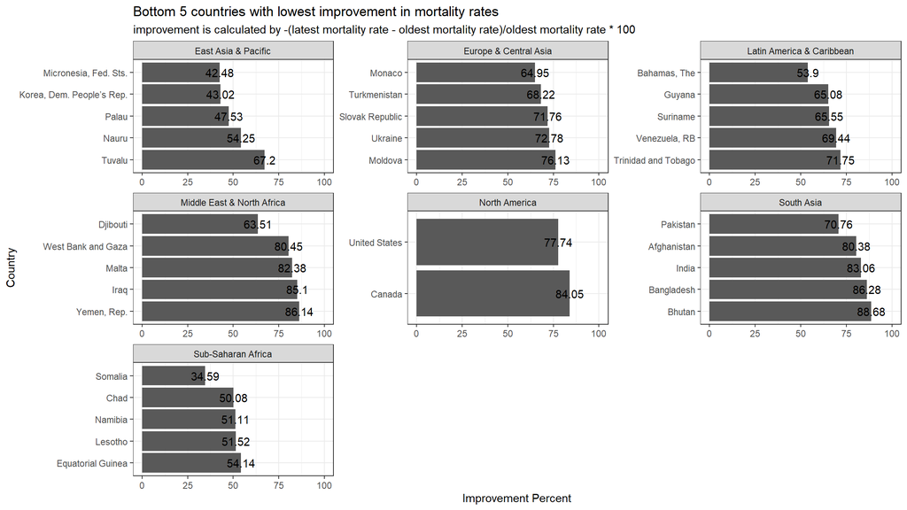

```r
ggplot(bottom_5_improvements_by_region, aes(x=improvement, y=reorder(country, -improvement))) +
  geom_col() +
  xlim(0, 100) +
  facet_wrap(~region, scales = "free") +
  labs(title="Bottom 5 countries with lowest improvement in mortality rates",
       subtitle="improvement is calculated by -(latest mortality rate - oldest mortality rate)/oldest mortality rate * 100",
       x = "Improvement Percent",
       y = "Country") +
  geom_text(aes(label = improvement %>% round(2))) +
  theme_bw()
```

5. Relationship between primary school enrollment and fertility rate.

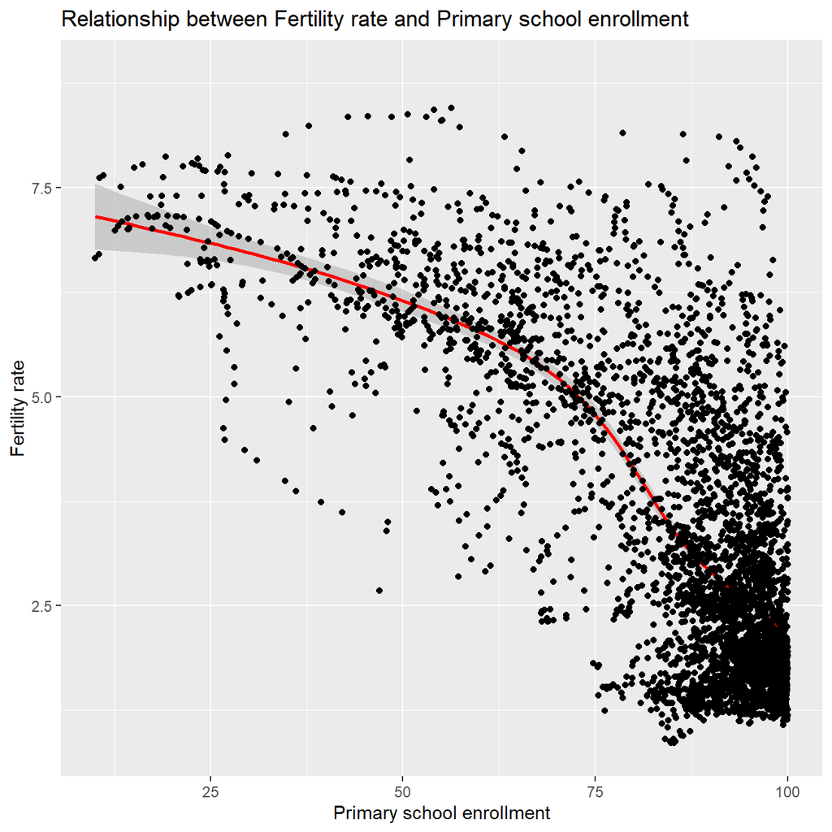

```r
ggplot(Combined_data_2, aes(x=SE.PRM.NENR,y=SP.DYN.TFRT.IN))+
    geom_smooth(colour="red")+
           geom_point()+
    labs(title="Relationship between Fertility rate and Primary school enrollment",x="Primary school enrollment",y="Fertility rate")
```

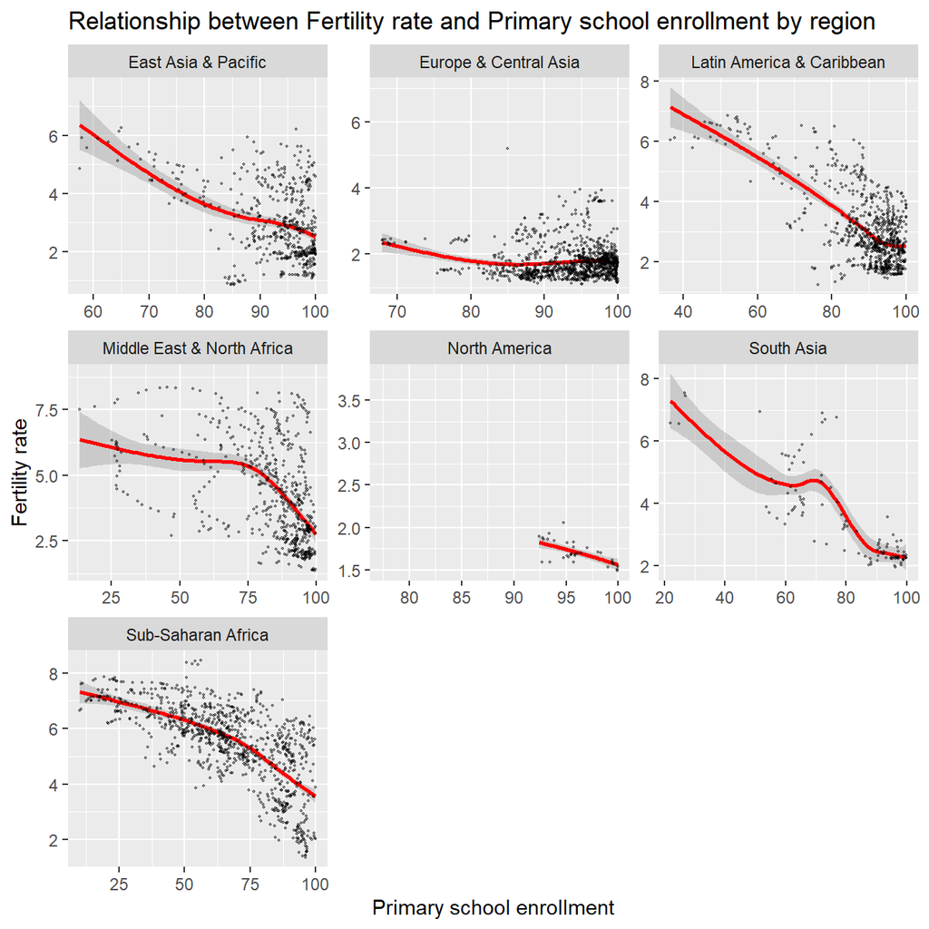

```r
ggplot(Combined_data_2, aes(x=SE.PRM.NENR,y=SP.DYN.TFRT.IN))+
    geom_smooth(colour="red")+
           geom_point(alpha=0.4, size=0.4)+
           facet_wrap(~region, scales="free")+
    labs(title="Relationship between Fertility rate and Primary school enrollment by region",x="Primary school enrollment",y="Fertility rate")
```

# 5 Challenge 1: CDC COVID-19 Public Use Data

```r
# file contains 11 variables and 3.66m rows and is well over 380Mb.
# It will take time to download

# URL link to CDC to download data
url <- "https://data.cdc.gov/api/views/vbim-akqf/rows.csv?accessType=DOWNLOAD"

covid_data <- vroom::vroom(url)%>% # If vroom::vroom(url) doesn't work, use read_csv(url)
  clean_names()
```

1. Graph by age group, sex, and whether the patient had co-morbidities or not

```r
glimpse(covid_data)
```

```
## Rows: 4,481,062
## Columns: 11
## $ cdc_report_dt               <date> 2020-03-22, 2020-03-23, 2020-03-15, 20...
## $ pos_spec_dt                 <date> 2020-03-15, 2020-03-15, 2020-03-15, 20...
## $ onset_dt                    <date> 2020-03-11, NA, NA, NA, NA, 2020-03-03...
## $ current_status              <chr> "Laboratory-confirmed case", "Laborator...
## $ sex                         <chr> "Female", "Female", "Female", "Female",...
## $ age_group                   <chr> "0 - 9 Years", "0 - 9 Years", "0 - 9 Ye...
## $ race_and_ethnicity_combined <chr> "Multiple/Other, Non-Hispanic", "Unknow...
## $ hosp_yn                     <chr> "Yes", "Unknown", "Missing", "Missing",...
## $ icu_yn                      <chr> "Yes", "Unknown", "Missing", "Missing",...
## $ death_yn                    <chr> "No", "Unknown", "Missing", "Missing", ...
## $ medcond_yn                  <chr> "Yes", "Unknown", "Missing", "Missing",...
```

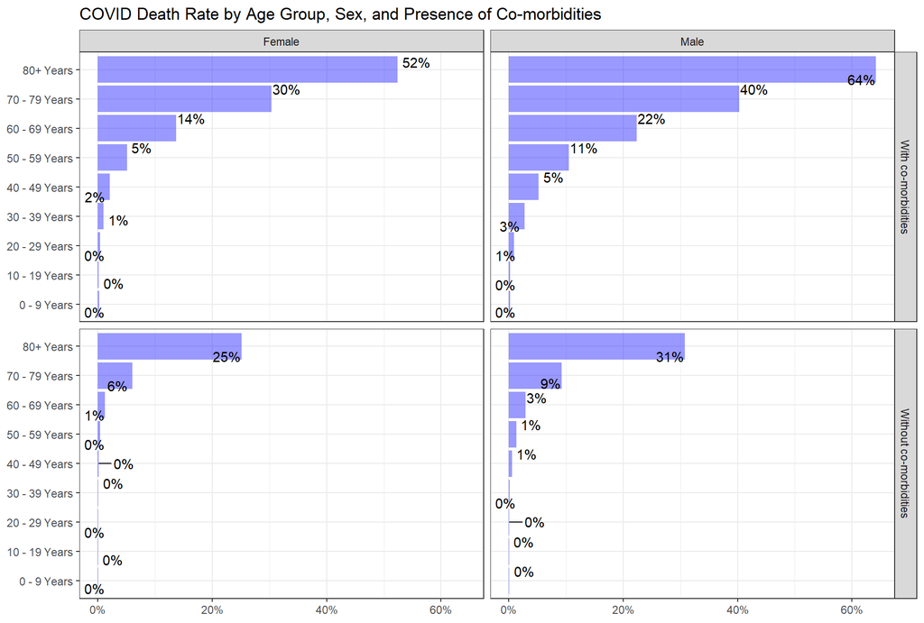

```r
covid_chart1 <- covid_data %>%
select(medcond_yn, death_yn, sex, age_group) %>%
        filter(!medcond_yn %in% c("Missing", "Unknown", "Other", NA),
               !sex %in% c("Missing", "Unknown", "Other", NA),
               !age_group %in% c("Missing", "Unknown", "Other", NA),
               !death_yn %in% c("Missing", "Unknown", "Other", NA)) %>%

  mutate(medcond_with = ifelse(medcond_yn=="Yes", "With co-morbidities", "Without co-morbidities")) %>%
  group_by(age_group, sex, medcond_with) %>%
  summarise(death = prop(death_yn, success = "Yes"), label = scales::percent(death %>% round(2)))


ggplot(covid_chart1, aes(x=death, y=age_group)) +
  geom_col(fill = "blue", alpha = 0.4) +
  facet_grid(rows= vars(medcond_with), cols= vars(sex)) +
  ggtitle("COVID Death Rate by Age Group, Sex, and Presence of Co-morbidities") +
  geom_text_repel(label = covid_chart1$label) +
  scale_x_continuous(labels = scales::percent) +
  labs(x = NULL, y = NULL) +
  theme_bw()
```

2. Graph by age group, sex, and whether the patient was admited to Intensive Care Unit (ICU) or not.

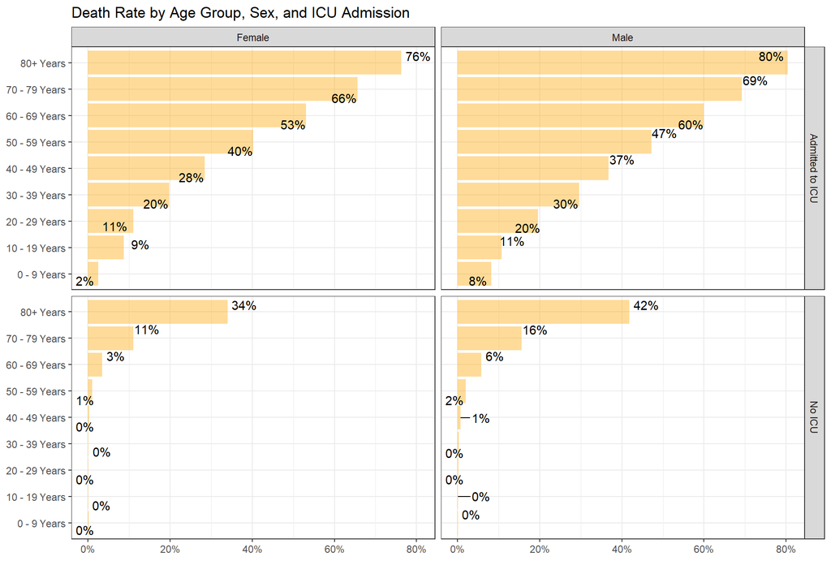

```r
covid_chart2 <- covid_data %>%
select(icu_yn, death_yn, sex, age_group) %>% na.omit() %>%
        filter(!icu_yn %in% c("Missing", "Unknown", "Other", NA),
               !sex %in% c("Missing", "Unknown", "Other", NA),
               !age_group %in% c("Missing", "Unknown", "Other", NA),
               !death_yn %in% c("Missing", "Unknown", "Other", NA)) %>%

  mutate(in_icu = ifelse(icu_yn=="Yes", "Admitted to ICU", "No ICU")) %>%
  group_by(age_group, sex, in_icu) %>%
  summarise(death = prop(death_yn, success = "Yes"), label = scales::percent(death %>% round(2)))


ggplot(covid_chart2, aes(x=death, y=age_group)) +
  geom_col(fill = "orange", alpha = 0.4) +
  facet_grid(rows= vars(in_icu), cols= vars(sex))+
  ggtitle("Death Rate by Age Group, Sex, and ICU Admission") +
  geom_text_repel(label = covid_chart2$label) +
  scale_x_continuous(labels = scales::percent) +
  labs(x=NULL, y=NULL) +
  theme_bw()
```

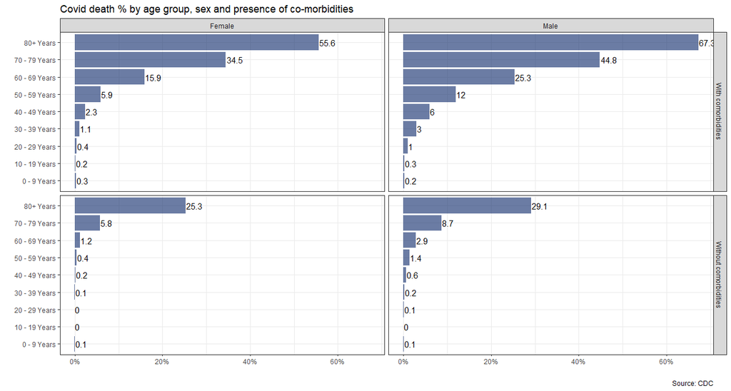

```r
knitr::include_graphics(here::here("images", "covid_death_rate_comorbidities.png"), error = FALSE)
```

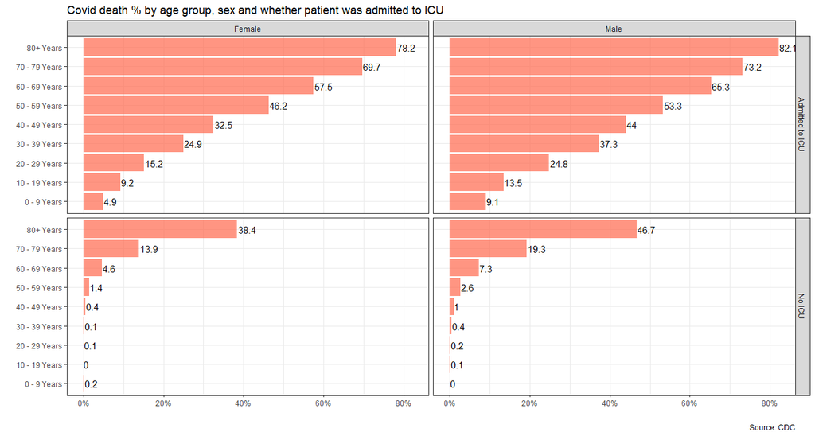

```r
knitr::include_graphics(here::here("images", "covid_death_rate_icu.png"), error = FALSE)
```

# 6 Challenge 2: Excess rentals in TfL bike sharing

```r
url <- "https://data.london.gov.uk/download/number-bicycle-hires/ac29363e-e0cb-47cc-a97a-e216d900a6b0/tfl-daily-cycle-hires.xlsx"

# Download TFL data to temporary file
httr::GET(url, write_disk(bike.temp <- tempfile(fileext = ".xlsx")))
```

```
## Response [https://airdrive-secure.s3-eu-west-1.amazonaws.com/london/dataset/number-bicycle-hires/2020-09-18T09%3A06%3A54/tfl-daily-cycle-hires.xlsx?X-Amz-Algorithm=AWS4-HMAC-SHA256&X-Amz-Credential=AKIAJJDIMAIVZJDICKHA%2F20201004%2Feu-west-1%2Fs3%2Faws4_request&X-Amz-Date=20201004T184140Z&X-Amz-E…
##   Date: 2020-10-04 18:44
##   Status: 200
##   Content-Type: application/vnd.openxmlformats-officedocument.spreadsheetml.sheet
##   Size: 165 kB
## <ON DISK>  C:\Users\deepa\AppData\Local\Temp\Rtmp0m4Edj\file3d5c4a20230d.xlsx
```

```r
# Use read_excel to read it as dataframe
bike0 <- read_excel(bike.temp,
                   sheet = "Data",
                   range = cell_cols("A:B"))

# change dates to get year, month, and week
bike <- bike0 %>%
  clean_names() %>%
  rename (bikes_hired = number_of_bicycle_hires) %>%
  mutate (year = year(day),
          month = lubridate::month(day, label = TRUE),
          week = isoweek(day))
```

Create a facet grid that plots bikes hired by month and year.

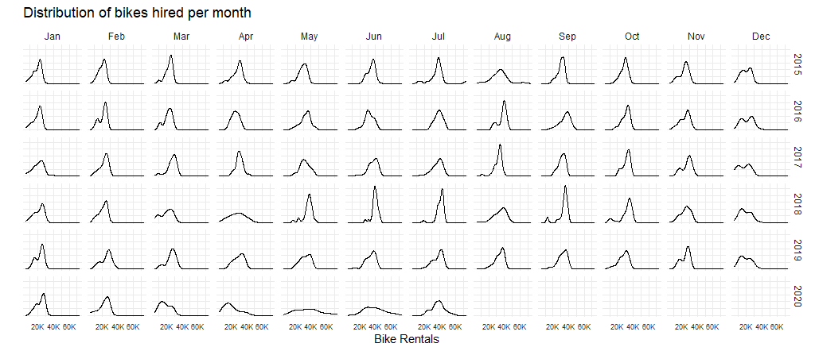

First few months of 2020 (Jan-Mar) look similar to previous years, but after that because of COVID, the variations (std deviation) is quite high as the curve is very wide.

Reproduce the following two graphs.

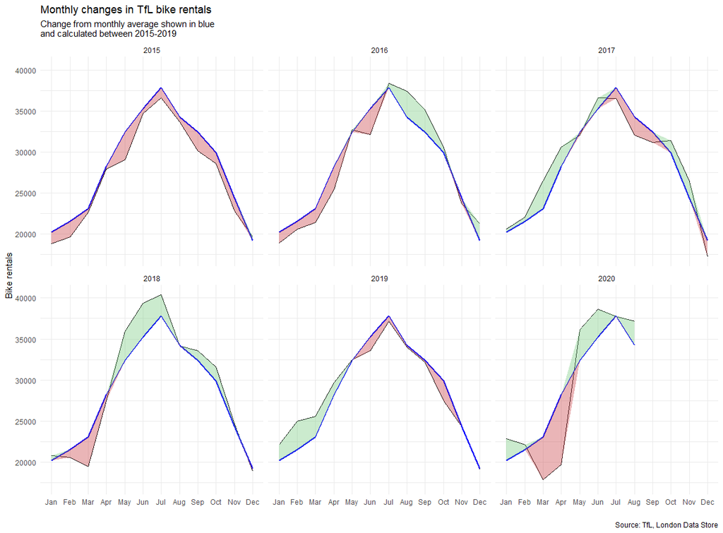

```r
knitr::include_graphics(here::here("images", "tfl_monthly.png"), error = FALSE)
```

```r
glimpse(bike)
```

```
## Rows: 3,686
## Columns: 5
## $ day         <dttm> 2010-07-30, 2010-07-31, 2010-08-01, 2010-08-02, 2010-0...
## $ bikes_hired <dbl> 6897, 5564, 4303, 6642, 7966, 7893, 8724, 9797, 6631, 7...
## $ year        <dbl> 2010, 2010, 2010, 2010, 2010, 2010, 2010, 2010, 2010, 2...
## $ month       <ord> Jul, Jul, Aug, Aug, Aug, Aug, Aug, Aug, Aug, Aug, Aug, ...
## $ week        <dbl> 30, 30, 30, 31, 31, 31, 31, 31, 31, 31, 32, 32, 32, 32,...
```

```r
expected_rentals_per_month_tbl <- bike %>% filter(year %in% c(2015, 2016, 2017, 2018, 2019)) %>% group_by(month) %>%
  summarise(expected_rentals = mean(bikes_hired))

expected_rentals_per_month_tbl
```

```
## # A tibble: 12 x 2
##    month expected_rentals
##    <ord>            <dbl>
##  1 Jan             20259.
##  2 Feb             21566.
##  3 Mar             23115.
##  4 Apr             28230.
##  5 May             32422.
##  6 Jun             35262.
##  7 Jul             37809.
##  8 Aug             34243.
##  9 Sep             32433.
## 10 Oct             29900.
## 11 Nov             24365.
## 12 Dec             19218.
```

```r
monthly_data <- bike %>% filter(year %in% c(2015, 2016, 2017, 2018, 2019, 2020)) %>%  group_by(year, month) %>%
  summarise(actual_rentals = mean(bikes_hired)) %>% full_join(expected_rentals_per_month_tbl, by = "month") %>%
  mutate(excess_rentals = actual_rentals-expected_rentals)

monthly_data
```

```
## # A tibble: 68 x 5
## # Groups:   year [6]
##     year month actual_rentals expected_rentals excess_rentals
##    <dbl> <ord>          <dbl>            <dbl>          <dbl>
##  1  2015 Jan           18828.           20259.         -1431.
##  2  2015 Feb           19617.           21566.         -1949.
##  3  2015 Mar           22625.           23115.          -490.
##  4  2015 Apr           27951.           28230.          -278.
##  5  2015 May           29031.           32422.         -3391.
##  6  2015 Jun           34659.           35262.          -604.
##  7  2015 Jul           36607.           37809.         -1202.
##  8  2015 Aug           33643.           34243.          -600.
##  9  2015 Sep           30114.           32433.         -2319.
## 10  2015 Oct           28560.           29900.         -1339.
## # ... with 58 more rows
```

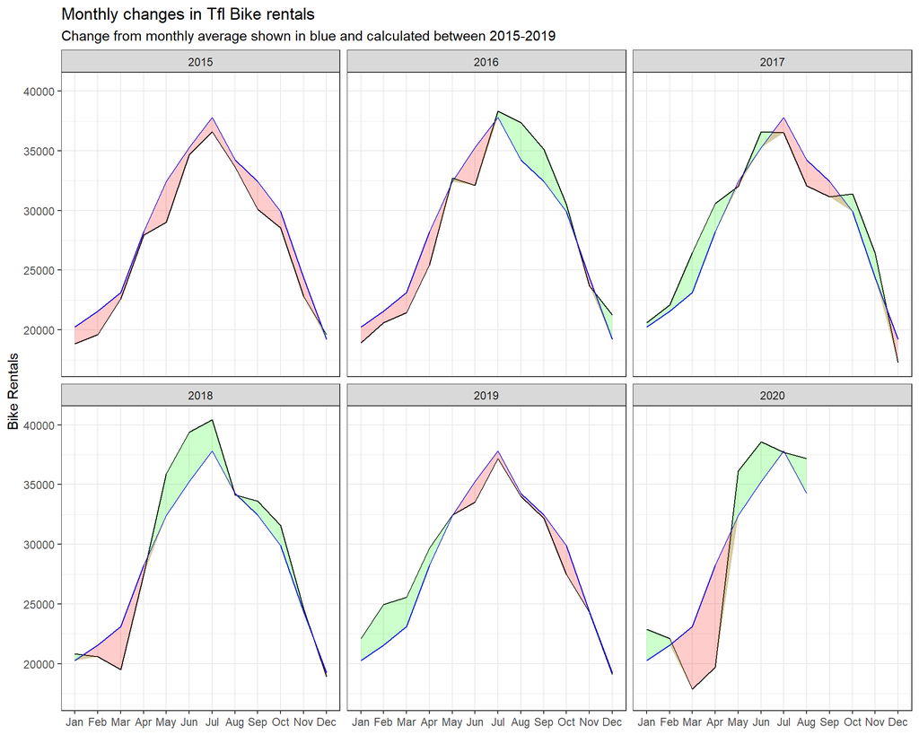

```r
ggplot(monthly_data, aes(x=month, y=actual_rentals, group=year)) +
  geom_line()+
  geom_line(aes(y=expected_rentals), color="blue") +
  facet_wrap(~year, nrow=2) +
  geom_ribbon(aes(ymin = ifelse(excess_rentals >= 0, expected_rentals, actual_rentals),
                  ymax = actual_rentals), alpha=0.2, fill="green") +
  geom_ribbon(aes(ymin = ifelse(excess_rentals >= 0, expected_rentals, actual_rentals),
                  ymax = expected_rentals), alpha=0.2, fill="red") +
  labs(title = "Monthly changes in Tfl Bike rentals",
       subtitle = "Change from monthly average shown in blue and calculated between 2015-2019",
       y = "Bike Rentals",
       x = NULL) +
  theme_bw() +
  NULL
```

The second one looks at percentage changes from the expected level of weekly rentals. The two grey shaded rectangles correspond to the second (weeks 14-26) and fourth (weeks 40-52) quarters.

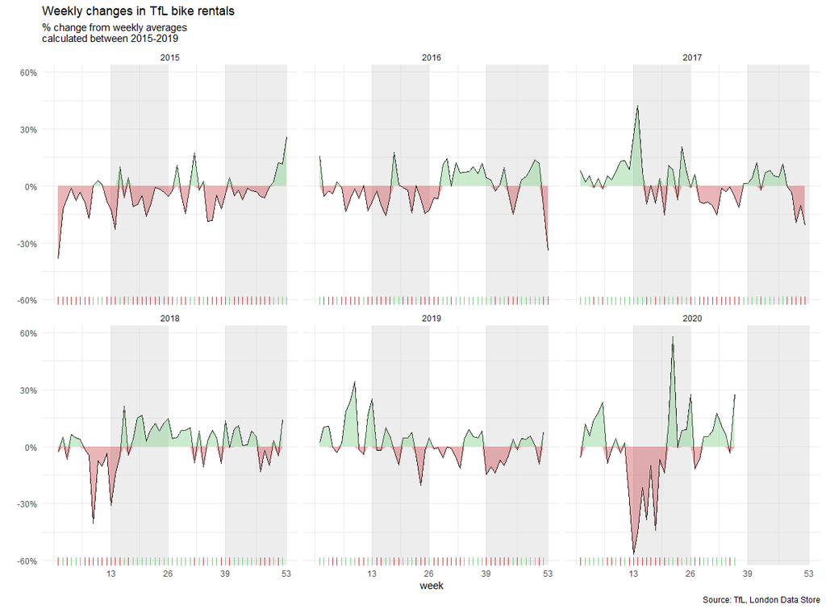

```r
knitr::include_graphics(here::here("images", "tfl_weekly.png"), error = FALSE)
```

```r
expected_rentals_per_week_tbl <- bike %>% filter(year %in% c(2015, 2016, 2017, 2018, 2019)) %>% group_by(week) %>%
  summarise(expected_rentals = mean(bikes_hired))

expected_rentals_per_week_tbl
```

```
## # A tibble: 53 x 2
##     week expected_rentals
##    <dbl>            <dbl>
##  1     1           16360.
##  2     2           21402.
##  3     3           21540.
##  4     4           21407.
##  5     5           20795.
##  6     6           20058.
##  7     7           22761.
##  8     8           22602.
##  9     9           20176.
## 10    10           23561.
## # ... with 43 more rows
```

```r
weekly_data <- bike %>% filter(year %in% c(2015, 2016, 2017, 2018, 2019, 2020)) %>%  group_by(year, week) %>%
  summarise(actual_rentals = mean(bikes_hired)) %>% full_join(expected_rentals_per_week_tbl, by = "week") %>%
  mutate(excess_rentals_percent = (actual_rentals-expected_rentals)/expected_rentals,
         color_id = ifelse(excess_rentals_percent >= 0, ">=0", "<0"))

weekly_data
```

```
## # A tibble: 298 x 6
## # Groups:   year [6]
##     year  week actual_rentals expected_rentals excess_rentals_percent color_id
##    <dbl> <dbl>          <dbl>            <dbl>                  <dbl> <chr>
##  1  2015     1         10038.           16360.               -0.386   <0
##  2  2015     2         18786.           21402.               -0.122   <0
##  3  2015     3         20131.           21540.               -0.0654  <0
##  4  2015     4         21158.           21407.               -0.0117  <0
##  5  2015     5         19201.           20795.               -0.0767  <0
##  6  2015     6         19386.           20058.               -0.0335  <0
##  7  2015     7         20787            22761.               -0.0867  <0
##  8  2015     8         18711.           22602.               -0.172   <0
##  9  2015     9         20213.           20176.                0.00181 >=0
## 10  2015    10         24196.           23561.                0.0269  >=0
## # ... with 288 more rows
```

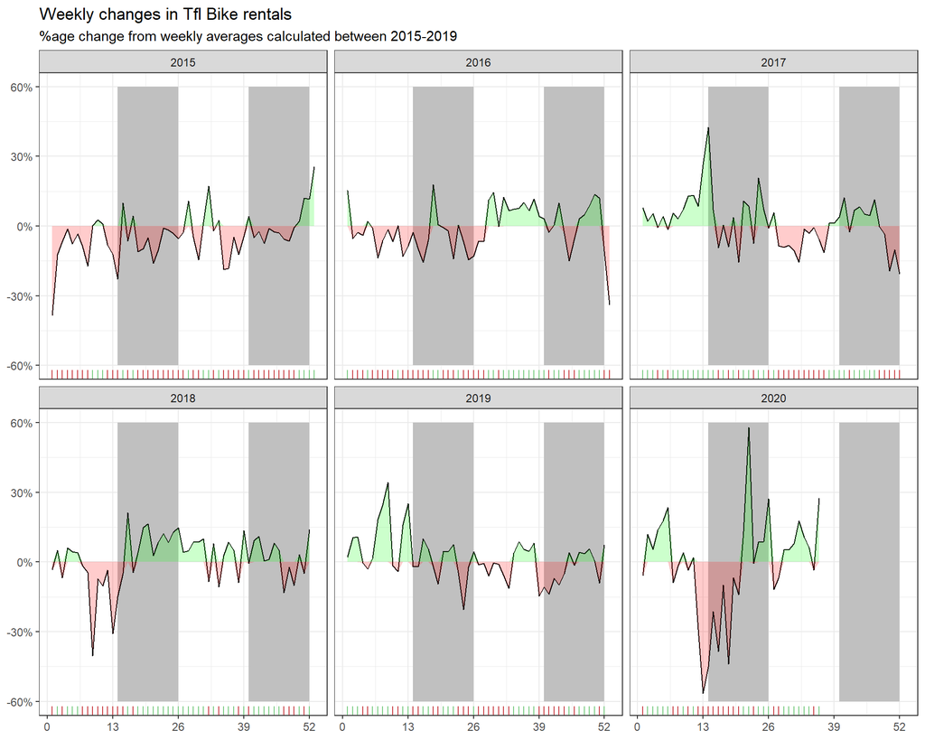

```r
ggplot(weekly_data, aes(x=week, y=excess_rentals_percent, group=year)) +
  geom_rect(aes(xmin=14, xmax=26, ymin=-0.6, ymax=0.6), show.legend = FALSE, alpha = 0.2, fill = "grey") +
  geom_rect(aes(xmin=40, xmax=52, ymin=-0.6, ymax=0.6), show.legend = FALSE, alpha = 0.2, fill = "grey") +
  geom_line(aes(y=excess_rentals_percent), color="black") +
  facet_wrap(~year, nrow=2) +
  geom_ribbon(aes(ymin = 0, ymax = ifelse(excess_rentals_percent >= 0, excess_rentals_percent, 0)),
              alpha=0.2, fill="green") +
  geom_ribbon(aes(ymin = ifelse(excess_rentals_percent < 0, excess_rentals_percent, 0),
                  ymax = 0), alpha=0.2, fill="red") +

  scale_fill_gradient(low = "white",high = "grey", limits=c(0,1)) +
  geom_rug(aes(color = color_id), sides="b", show.legend = FALSE) +
  scale_colour_manual(values=c("#CB454A","#7DCD85"), name="Actual vs Expected ", guide=FALSE) +
  scale_x_continuous(breaks = seq(0,53, by = 13)) +
  scale_y_continuous(labels = scales::percent) +
  labs(title = "Weekly changes in Tfl Bike rentals",
       subtitle = "%age change from weekly averages calculated between 2015-2019",
       y = NULL,
       x = NULL) +
  theme_bw() +
  NULL
```

I have used ‘mean’ here because then my chart matches with the image, but I’d have preferred to use median because mean gets distorted due to outliers while median doesn’t.

# 7 Details

- Who did you collaborate with: DEEPAK GUNEJA, WARREN HU, JUSTINE VEYRENC, RICCARDO PERSICO, ALEX SKLAVOUNOS, CHENYING LI
- Approximately how much time did you spend on this problem set: 20 hours
- What, if anything, gave you the most trouble: Replicating images